# Project 4 - Spam Email

# Overview

During this project we’re going to use a set of spam and normal (ham) emails to predict whether an email is spam or not. We’re using a set of example emails, which were downloaded from https://spamassassin.apache.org/old/publiccorpus/.

# Libraries Needed:

- tm
- dplyr
- tidyverse
- stringr
- tidytext
- tidyverse
- caTools
- e1071
- wordcloud
- RColorBrewer

This function will be used to remove a lot of the text which is related to sending an email. We don’t want to analyze this because it’s not the actual text in an email.

```r
#read in text and remove header email formatting that isn't related to email text
cleanEmails <- function(text){
  for (i in 1:length(text)){
    for (j in 1:dim(text[[i]][1])[1]){

      if (str_detect(text[[i]][j,],'^From:') == TRUE){

        text[[i]] <- text[[i]][j:dim(text[[i]][1])[1],]

        break
      }
    }
    next
  }
}
```

# Get Spam Data

These emails were originally downloaded from https://spamassassin.apache.org/old/publiccorpus/

```r
#get file paths of spam emails
spam_emails <- str_replace_all(paste(getwd(),"/Data/spam_2/",list.files("Data/spam_2"))," ","")

spam <- lapply(spam_emails,read_csv)

cleanEmails(spam)
```

## Create spam corpus

```r
#create spam corpus
spam_corpus <- VCorpus(VectorSource(spam))

#create document term matrix using spam corpus
spam_dtm <- DocumentTermMatrix(spam_corpus)

#create tidy dtm with column to flag if email is spam or not
tidy_spam_dtm <- tidy(spam_dtm)
tidy_spam_dtm$spam <- 1

#replace commas and quotations
tidy_spam_dtm$term <- str_replace_all(tidy_spam_dtm$term,",","")
tidy_spam_dtm$term <- str_replace_all(tidy_spam_dtm$term,"'","")
tidy_spam_dtm$term <- str_replace_all(tidy_spam_dtm$term,'"','')
tidy_spam_dtm$term <- str_replace_all(tidy_spam_dtm$term,'\\(','')
tidy_spam_dtm$term <- str_replace_all(tidy_spam_dtm$term,'\\)','')
tidy_spam_dtm$term <- str_replace_all(tidy_spam_dtm$term,'\\{','')
tidy_spam_dtm$term <- str_replace_all(tidy_spam_dtm$term,'\\}','')
tidy_spam_dtm$term <- str_replace_all(tidy_spam_dtm$term,';','')

#make all words lowercase
#tidy_spam_dtm$term <- toLower(tidy_spam_dtm$term)
```

# Get Non-Spam (Ham) Email Data

These are non-spam emails

```r
#get file paths of ham emails (non-spam)
ham_emails <- str_replace_all(paste(getwd(),"/Data/easy_ham/",list.files("Data/easy_ham"))," ","")

#read in ham emails (non-spam)
ham <- lapply(ham_emails,read_csv)

cleanEmails(ham)
```

## Create ham corpus

```r
#create ham corpus
ham_corpus <- VCorpus(VectorSource(ham))

#create document term matrix using ham corpus
ham_dtm <- DocumentTermMatrix(ham_corpus)

#create tidy dtm with column to flag if email is spam or not
tidy_ham_dtm <- tidy(ham_dtm)
tidy_ham_dtm$spam <- 0

#replace commas and quotations
tidy_ham_dtm$term <- str_replace_all(tidy_ham_dtm$term,",","")
tidy_ham_dtm$term <- str_replace_all(tidy_ham_dtm$term,"'","")
tidy_ham_dtm$term <- str_replace_all(tidy_ham_dtm$term,'"','')
tidy_ham_dtm$term <- str_replace_all(tidy_ham_dtm$term,"\\(","")
tidy_ham_dtm$term <- str_replace_all(tidy_ham_dtm$term,"\\)","")
tidy_ham_dtm$term <- str_replace_all(tidy_ham_dtm$term,"\\{","")
tidy_ham_dtm$term <- str_replace_all(tidy_ham_dtm$term,"\\}","")
tidy_ham_dtm$term <- str_replace_all(tidy_ham_dtm$term,";","")

#make all words lowercase
#tidy_ham_dtm$term <- toLower(tidy_ham_dtm$term)
```

# Remove Stop Words

Below we’re going to remove common words relating to email formats.

```r
stopwords <- tidytext::get_stopwords(language = "en",source = "smart")
stopwords <- bind_rows(tibble(word = c("From:","Re:","Email:","Received:","cc:","date:"),
                              lexicon = c("custom","custom","custom","custom","custom","custom")),
                              stopwords)
```

# Combine the ham and spam document

```r
combo_tidy_dtm <- rbind(tidy_ham_dtm,tidy_spam_dtm)

#remove stop words
combo_tidy_dtm <- combo_tidy_dtm %>% anti_join(stopwords,by = c(term = 'word'))

combo_tidy_dtm <- combo_tidy_dtm %>% filter(!str_detect(term,"[\\d]"))
combo_tidy_dtm <- combo_tidy_dtm %>% filter(!str_detect(term,"[\\-]"))
combo_tidy_dtm <- combo_tidy_dtm %>% filter(!str_detect(term,"[<|>]"))
combo_tidy_dtm <- combo_tidy_dtm %>% filter(!str_detect(term,"[\\\\]"))
combo_tidy_dtm <- combo_tidy_dtm %>% filter(!str_detect(term,"[\\.]"))
combo_tidy_dtm <- combo_tidy_dtm %>% filter(!str_detect(term,"[:]"))
combo_tidy_dtm <- combo_tidy_dtm %>% filter(!str_detect(term,"[+]"))
combo_tidy_dtm <- combo_tidy_dtm %>% filter(!str_detect(term,"^...$"))
```

# Spam Word Cloud

Here we generate a Word Cloud Based on Spam Words. The most frequent spam words are:

Some of these words may be related to the email but some make sense. Spam emails try to get users to **click** and give **money**.

```r
term_count <- combo_tidy_dtm %>%
  group_by(term) %>%
  select(term,count,spam) %>%
  filter(spam == 1) %>%
  summarize(term_count = sum(count))

term_count %>%
  arrange(-term_count,term)
```

```
## # A tibble: 14,014 x 2
##    term      term_count
##    <chr>          <dbl>
##  1 =               4317
##  2 esmtp           3138
##  3 email           1827
##  4 localhost       1745
##  5 mv              1398
##  6 smtp            1283
##  7 free            1195
##  8 postfix          966
##  9 list             875
## 10 na               861
## # … with 14,004 more rows
```

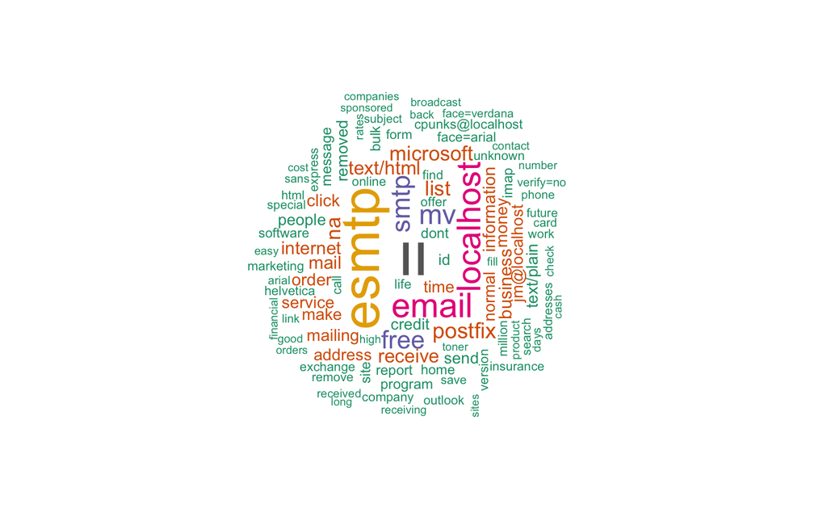

```r
wordcloud(words = term_count$term, freq = term_count$term_count, min.freq = 1, max.words=100, random.order=FALSE, rot.per=0.35,            colors=brewer.pal(8, "Dark2"))
```

```r
#email_tidy <- combo_tidy_dtm %>%
#  group_by(document,spam) %>%
#  top_n(5,count) %>%
#  arrange(document,spam,-count)
```

# Setting up test & training data

We’re going to separate the data into 75% training and 25% test data.

```r
set.seed(101)
sample = sample.split(combo_tidy_dtm$term, SplitRatio = .75)
train = subset(combo_tidy_dtm, sample == TRUE)
test  = subset(combo_tidy_dtm, sample == FALSE)
```

# Prediction

```r
prop.table(table(combo_tidy_dtm$spam)) * 100
```

```
##
##       0       1
## 59.9231 40.0769
```

```r
naiveBayes <- naiveBayes(train, factor(train$spam))
predict <- predict(naiveBayes,test)
table(predict, test$spam)
```

```
##
## predict     0     1
##       0 36996    12
##       1     0 25002
```

## Resources

- https://stackoverflow.com/questions/17200114/how-to-split-data-into-training-testing-sets-using-sample-function
- https://www.edureka.co/blog/naive-bayes-in-r/
- https://spamassassin.apache.org/old/publiccorpus/